# Clustering and Enrichment Analysis

Gianluca

2025-05-14

```r
suppressPackageStartupMessages({
  library(GenomicRanges)
  library(epiwraps)
  library(ggplot2)
  library(rGREAT)
})

setwd("C:/Users/gianl/Desktop/ETH/BiologyMsc/Spring Semester Material/BARGE/Assignments/week10")
download.file("https://ethz-ins.org/content/w10.assignment.zip", "w10.assignment.zip")
unzip("w10.assignment.zip")
```

# Data Processing and First Visualisation

```r
tracks <- list.files(pattern = "bw$")
peaks <- list.files(pattern="bed$")
# we first import the peaks
peaks <- lapply(peaks, rtracklayer::import.bed)
# we'll focus on the high-quality peaks
peaks <- lapply(peaks, FUN=function(x) x[x$score>800])
# we get the union of non-redundant regions
regions <- reduce(unlist(GRangesList(peaks)))

signal_matrix <- signal2Matrix(tracks, regions, extend = 2000)
```

```
## Reading Creb1.bw
```

```
## Reading Creb3.bw
```

```
## Reading Creb3L1.bw
```

```
## 'magick' package is suggested to install to give better rasterization.
##
## Set `ht_opt$message = FALSE` to turn off this message.
```

```
## 'magick' package is suggested to install to give better rasterization.
##
## Set `ht_opt$message = FALSE` to turn off this message.
## 'magick' package is suggested to install to give better rasterization.
##
## Set `ht_opt$message = FALSE` to turn off this message.
```

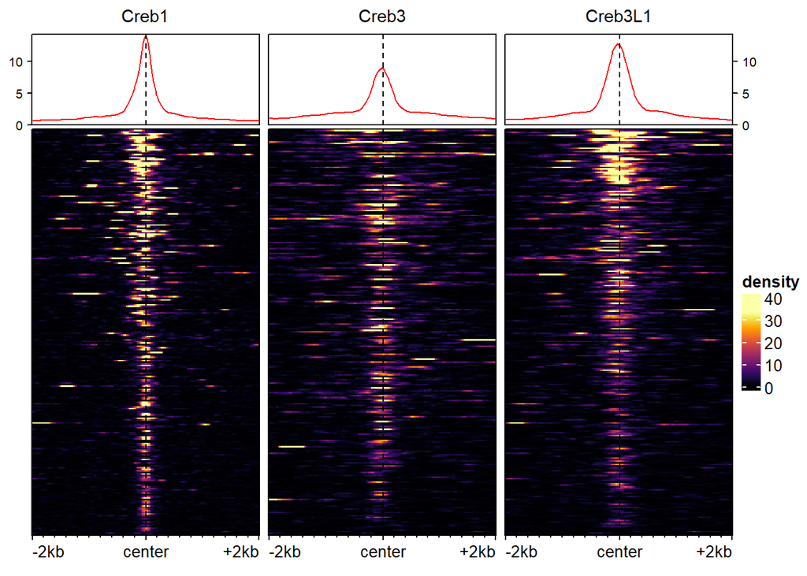

```r
plotEnrichedHeatmaps(signal_matrix)
```

# Clustering

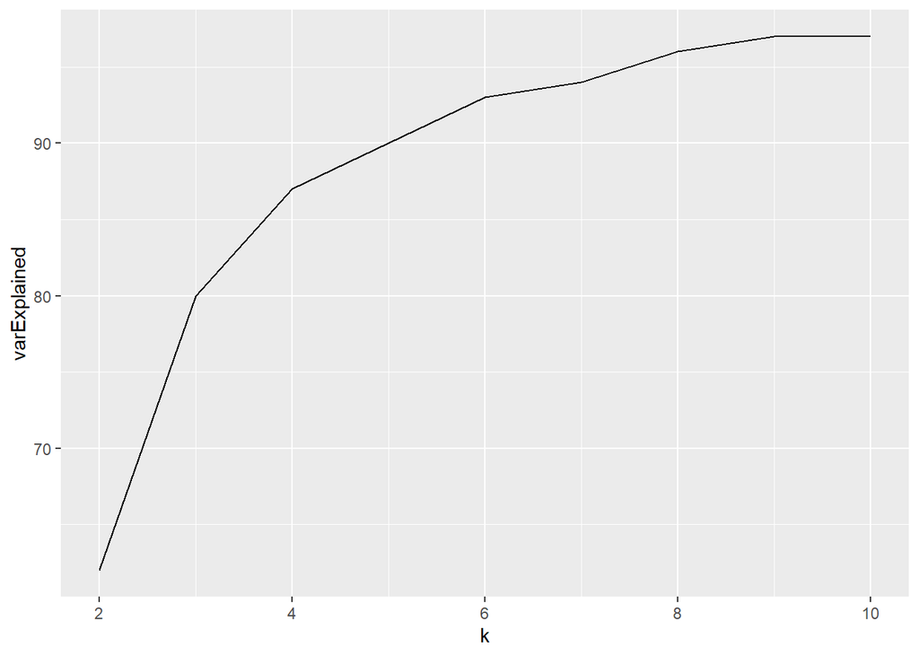

```r
set.seed(123) # ensures reproducibility

cl_test <- clusterSignalMatrices(signal_matrix, k=2:10, scaleRows = TRUE)
ggplot(cl_test$varExplained, aes(k, varExplained)) + geom_line()
```

```r
# with 4 clusters we can explain already more than 80% of variance
```

```r
cl <- clusterSignalMatrices(signal_matrix, k=4, scaleRows = TRUE)
```

```
##   ~87% of the variance explained by clusters
```

```r
table(cl)
```

```
## cl
##   1   2   3   4
## 389 684 383 813
```

```r
head(cl)
```

```
## [1] 4 4 1 1 1 4
## Levels: 1 2 3 4
```

```r
length(cl)
```

```
## [1] 2269
```

```r
length(regions)
```

```
## [1] 2269
```

```
## 'magick' package is suggested to install to give better rasterization.
##
## Set `ht_opt$message = FALSE` to turn off this message.
```

```
## 'magick' package is suggested to install to give better rasterization.
##
## Set `ht_opt$message = FALSE` to turn off this message.
## 'magick' package is suggested to install to give better rasterization.
##
## Set `ht_opt$message = FALSE` to turn off this message.
```

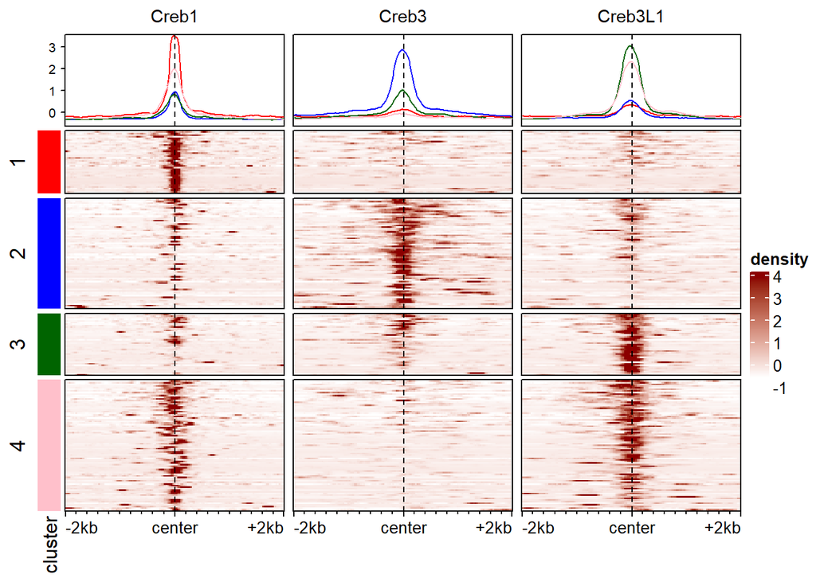

```r
rowData(signal_matrix)$cluster <- cl

mycolors <- c("1"="red", "2"="blue", "3"="darkgreen", "4"="pink")

plotEnrichedHeatmaps(signal_matrix, mean_color=mycolors, row_split=rowData(signal_matrix)$cluster,
                     colors=c("white","darkred"), scale_rows = "global")
```

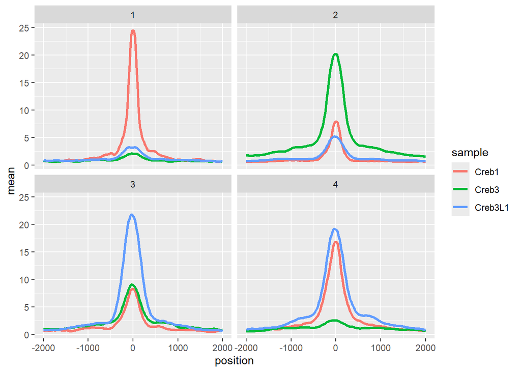

```r
d <- meltSignals(signal_matrix, splitBy = cl)
ggplot(d, aes(position, mean, colour = sample)) + geom_line(size=1.2) + facet_wrap(~split)
```

# GO Enrichment Analysis

```r
# split clusters to use as groups for GO enrichment analysis

split_regions <- split(rowRanges(signal_matrix), rowData(signal_matrix)$cluster)

res <- great(split_regions[["1"]], gene_sets="GO:BP", tss_source="mm10",
             background=regions, cores=2)
```

```
## * TSS source: TxDb.
```

```
## * check whether TxDb package 'TxDb.Mmusculus.UCSC.mm10.knownGene' is installed.
```

```
## * gene ID type in the extended TSS is 'Entrez Gene ID'.
```

```
## * restrict chromosomes to 'chr1, chr2, chr3, chr4, chr5, chr6, chr7, chr8, chr9, chr10,
##     chr11, chr12, chr13, chr14, chr15, chr16, chr17, chr18, chr19, chrX, chrY, chrM'.
```

```
## * 20590/24515 protein-coding genes left.
```

```
## * update seqinfo to the selected chromosomes.
```

```
## * TSS extension mode is 'basalPlusExt'.
```

```
## * construct the basal domains by extending 5000bp to upstream and 1000bp to downsteram of TSS.
```

```
## * calculate distances to neighbour regions.
```

```
## * extend to both sides until reaching the neighbour genes or to the maximal extension.
```

```
## * use GO:BP ontology with 15654 gene sets (source: org.Mm.eg.db).
```

```
## * check gene ID type in `gene_sets` and in `extended_tss`.
```

```
## * use self-defined background regions.
```

```
## * remove excluded regions from background.
```

```
## * overlap `gr` to background regions (based on midpoint).
```

```
## * in total 376 `gr`.
```

```
## * overlap extended TSS to background regions.
```

```
## * check which genes are in the gene sets.
```

```
## * only take gene sets with size >= 5.
```

```
## * in total 1295 gene sets.
```

```
## * overlap `gr` to every extended TSS.
```

```
## * perform binomial test for each biological term.
```

```r
res3 <- great(split_regions[["3"]], gene_sets = "GO:BP", tss_source = "mm10", background = regions, cores = 4)
```

```
## * TSS source: TxDb.
```

```
## * extended_tss is already cached, directly use it.
```

```
## * use GO:BP ontology with 15654 gene sets (source: org.Mm.eg.db).
```

```
## * check gene ID type in `gene_sets` and in `extended_tss`.
```

```
## * use self-defined background regions.
```

```
## * remove excluded regions from background.
```

```
## * overlap `gr` to background regions (based on midpoint).
```

```
## * in total 370 `gr`.
```

```
## * overlap extended TSS to background regions.
```

```
## * check which genes are in the gene sets.
```

```
## * only take gene sets with size >= 5.
```

```
## * in total 1295 gene sets.
```

```
## * overlap `gr` to every extended TSS.
```

```
## * perform binomial test for each biological term.
```

```r
res4 <- great(split_regions[["4"]], gene_sets = "GO:BP", tss_source = "mm10", background = regions, cores = 2)
```

```
## * TSS source: TxDb.
```

```
## * extended_tss is already cached, directly use it.
```

```
## * use GO:BP ontology with 15654 gene sets (source: org.Mm.eg.db).
```

```
## * check gene ID type in `gene_sets` and in `extended_tss`.
```

```
## * use self-defined background regions.
```

```
## * remove excluded regions from background.
```

```
## * overlap `gr` to background regions (based on midpoint).
```

```
## * in total 774 `gr`.
```

```
## * overlap extended TSS to background regions.
```

```
## * check which genes are in the gene sets.
```

```
## * only take gene sets with size >= 5.
```

```
## * in total 1295 gene sets.
```

```
## * overlap `gr` to every extended TSS.
```

```
## * perform binomial test for each biological term.
```

```r
# enrichment analysis
bp <- getEnrichmentTables(res)
bp3 <- getEnrichmentTable(res3)
bp4 <- getEnrichmentTable(res4)
head(bp)
```

```
##           id                               description genome_fraction
## 1 GO:0006812               monoatomic cation transport      0.07675911
## 2 GO:0098655 monoatomic cation transmembrane transport      0.06469891
## 3 GO:0006813                   potassium ion transport      0.02530104
## 4 GO:0071805     potassium ion transmembrane transport      0.02530104
## 5 GO:0098662  inorganic cation transmembrane transport      0.06435209
## 6 GO:0006811                  monoatomic ion transport      0.07913702
##   observed_region_hits fold_enrichment      p_value  p_adjust mean_tss_dist
## 1                   48        1.663120 0.0004007918 0.1174793        251599
## 2                   42        1.726492 0.0004511644 0.1174793        253308
## 3                   21        2.207461 0.0007331955 0.1174793        265638
## 4                   21        2.207461 0.0007331955 0.1174793        265638
## 5                   41        1.694468 0.0007589489 0.1174793        259192
## 6                   48        1.613146 0.0007732342 0.1174793        251599
##   observed_gene_hits gene_set_size fold_enrichment_hyper p_value_hyper
## 1                 21            31              1.383065    0.02362628
## 2                 18            27              1.361111    0.04458774
## 3                  7            11              1.299242    0.24940943
## 4                  7            11              1.299242    0.24940943
## 5                 17            26              1.334936    0.06400650
## 6                 21            34              1.261029    0.08540349
##   p_adjust_hyper
## 1       0.692896
## 2       0.692896
## 3       0.751120
## 4       0.751120
## 5       0.692896
## 6       0.692896
```

```r
head(bp3)
```

```
##           id                                   description genome_fraction
## 1 GO:0009895      negative regulation of catabolic process     0.009478437
## 2 GO:0045596   negative regulation of cell differentiation     0.055373589
## 3 GO:0030098                    lymphocyte differentiation     0.030693311
## 4 GO:1903313 positive regulation of mRNA metabolic process     0.006894834
## 5 GO:0032623                      interleukin-2 production     0.010836189
## 6 GO:0060070               canonical Wnt signaling pathway     0.012895876
##   observed_region_hits fold_enrichment     p_value p_adjust mean_tss_dist
## 1                   10        2.851422 0.003190586 0.812837        107633
## 2                   32        1.561873 0.009129546 0.812837        225141
## 3                   20        1.761102 0.011449116 0.812837        221236
## 4                    7        2.743927 0.015306206 0.812837         53749
## 5                    9        2.244731 0.020995135 0.812837         84102
## 6                   10        2.095788 0.023461838 0.812837        205352
##   observed_gene_hits gene_set_size fold_enrichment_hyper p_value_hyper
## 1                  6            10             1.3611111     0.2401850
## 2                 12            25             1.0888889     0.4188351
## 3                  6            15             0.9074074     0.7185037
## 4                  2             6             0.7561728     0.8264208
## 5                  4             5             1.8148148     0.1210047
## 6                  2             5             0.9074074     0.7310354
##   p_adjust_hyper
## 1      0.8748830
## 2      0.8748830
## 3      0.9247822
## 4      0.9563675
## 5      0.8663597
## 6      0.9247822
```

```r
head(bp4)
```

```
##           id                              description genome_fraction
## 1 GO:0031032        actomyosin structure organization     0.008716546
## 2 GO:0065008         regulation of biological quality     0.173703702
## 3 GO:0009057          macromolecule catabolic process     0.064599293
## 4 GO:0034976 response to endoplasmic reticulum stress     0.013813650
## 5 GO:0006417                regulation of translation     0.011177472
## 6 GO:0099536                       synaptic signaling     0.049108745
##   observed_region_hits fold_enrichment     p_value  p_adjust mean_tss_dist
## 1                   15        2.223340 0.003963048 0.8429733         97469
## 2                  163        1.212377 0.004598696 0.8429733        190499
## 3                   69        1.380004 0.004796628 0.8429733         97338
## 4                   19        1.777069 0.013042225 0.8429733        124879
## 5                   16        1.849420 0.015474510 0.8429733        109254
## 6                   52        1.368055 0.015486470 0.8429733        213740
##   observed_gene_hits gene_set_size fold_enrichment_hyper p_value_hyper
## 1                  5             6             1.3172043     0.2859886
## 2                 45            72             0.9879032     0.6124156
## 3                 24            35             1.0838710     0.3148027
## 4                  5             6             1.3172043     0.2859886
## 5                  7            11             1.0058651     0.6231091
## 6                 11            15             1.1591398     0.2978909
##   p_adjust_hyper
## 1      0.9020036
## 2      0.9020036
## 3      0.9020036
## 4      0.9020036
## 5      0.9020036
## 6      0.9020036
```

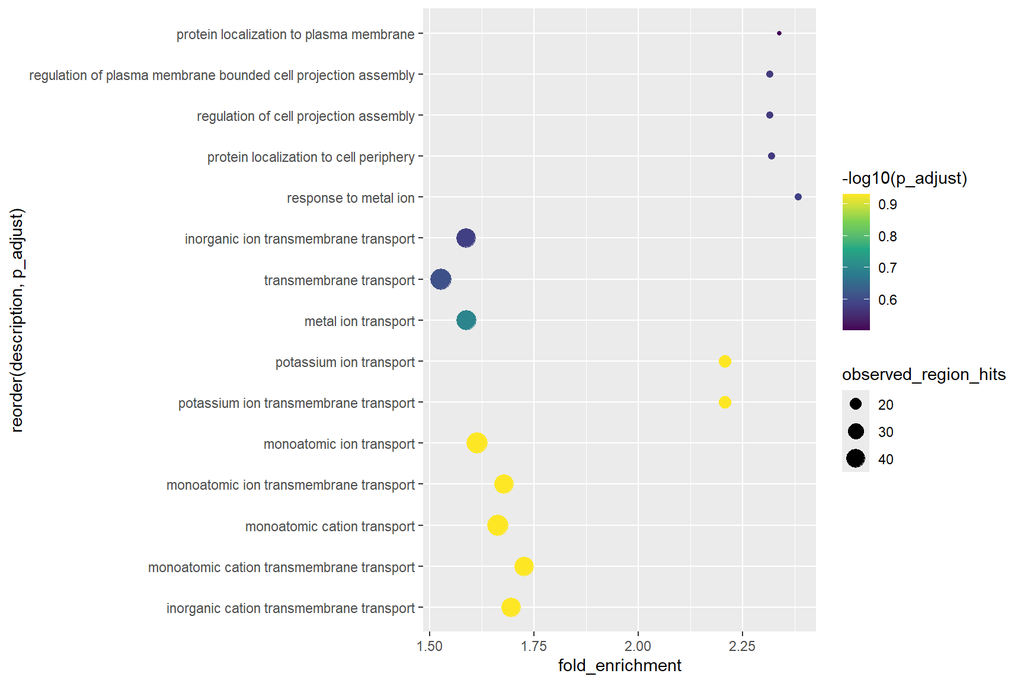

```r
ggplot(head(bp,15), aes(fold_enrichment, reorder(description, p_adjust),
                        size=observed_region_hits, color=-log10(p_adjust))) +
  geom_point() + scale_color_viridis_c()
```

# Comment

Either three of the TFs can occur mostly by itself in a genomic regions, as we see for cluster 1-3, with very little signal from either one of the other TFs. Nonetheless, Creb1 and Creb3L1 can instead co-occur in a genomic region, which could be the result of competition for the same locus or cooperation. The GO enrichment analysis shows us that for cluster 1, characterised by high Creb1 signal, is mostly enirched for ion exchange processes. Cluster 3 that has high signals of Creb3L1, is enriched for biological processes that seem related to cell differentiation. On the other hand cluster 4 shows a high signal for both Creb1 and Creb3L1. Some biological processes relate to one of the two TF, for example “synaptic signalling” to some extent can be related to ion exchange processes, most specifically to potassium exchange which is indicate in the GO enrichment of cluster 1. The most enriched biological process in cluster 4 is instead “actomyosin structure organisation”, which to me seems something unique to this cluster and hence might be a result of cooperation between Creb1 and Creb3L1.